# Homework 1 (712): Impact of ceasefire weekends on gun homicide rates

#### Preface

- **This homework is due Friday November 8, 2019 at 11:59 PM**.
- When you have completed the assignment, knit the R Markdown, commit your changes and push to GitHub.
- If you do not include axis labels and plot titles, then points will be deducted.
- You are welcome and encouraged to discuss homework problems with others in order to better understand it, but the work you turn in must be your own. You must write your own code, data analyses, and communicate and explain the results in your own words and with your own visualizations. **All students turning in plagiarized solutions will be reported to Office of Academic Integrity, and will fail the assignment**.

# Motivation

[figure not shown]

[[source](https://www.thetrace.org/wp-content/uploads/2017/07/76044401-1280x0-c-default.png)]

In 2017, Baltimore put out a city-wide call asking for Baltimore residents to avoid having any murders through quarterly Ceasefires and Peace Challenges (February, May, August, and November). This became known as [Baltimore Ceasefire 365](https://baltimoreceasefire.com).

Imagine you are a data scientist working for the city of Baltimore where you help government officials implement and evaluate policies rolled out by looking and analyzing data. Recently, you have been contacted by [Monica Valdes Lupi, the Executive Director from the Boston Public Health Commission](https://www.bphc.org/aboutus/office-director/Pages/office--of-director.aspx) who is interested in exploring the idea of implementing a similar city-wide ceasefire call in Boston to reduce gun deaths. She wants to know

- Do the Baltimore ceasefires lead to a reduction in gun-related murders? Can you quantify any change in gun-related deaths during ceasefire weekends?
- Is this a city-wide call you would recommend Boston implement in their own city? Is there any data that would suggest that such a policy would or would not be effective in Boston?
- Is there anything else that should be considered before making any decision about this policy?

In this homework assignment, you will be exploring these questions, summarizing your results, and giving a final recommendation to Monica.

**Helpful hints**: You will find the [Open Baltimore data](https://data.baltimorecity.gov) useful for obtain crime data on shootings or homicides with a firearm.

# Presentation

You will need present a draft of your analysis in class on **November 6, 2019** using the [slide template provided here](https://docs.google.com/presentation/d/1zB855yWJ27b6VYA0iqFuKPh1REaLYkyh_5D-qQd5bkE/edit?usp=sharing).

- Everyone has to use the format that the slide template provides, but you do not need to use Google Slides if you don’t want to.
- Each person will have 3 minutes to present with 1 minute for questions.
- Before class on November 6, 2019, please [submit a link to your slides using this form](https://forms.gle/HkVSoh5wQKLqqaHY6).

# Analysis

Baltimore’s first Ceasefire Weekend took place in August 2017. Since then, every Friday, Saturday, and Sunday on the 1st weekend of the month in February, August, and November and Mother’s Day weekend (Friday, Saturday, and Sunday) in May has been denoted a Ceasefire Weekend. This adds up to a total of nine Ceasefire Weekends as of Oct 30, 2019. The dates of the past Ceasefire Weekends are listed below:  
August 4-6, 2017  
November 3-5, 2017  
February 2-4, 2018  
May 11-13, 2018  
August 3-5, 2018  
November 2-4, 2018  
February 1-3, 2019  
May 10-12, 2019  
August 2-4, 2019

To analyze the impact of the ceasefires, I obtained Baltimore homicide data from: https://data.baltimorecity.gov/Crime/Homicides-2013-Present/33zm-qy8h. This analysis uses data downloaded on 10/30/2019, which contains 1,802 observations.

```r
# load R packages
library(readr)
library(tidyverse)
library(lubridate)
library(scales)
library(chron)
library(reshape)
library(kableExtra)

# load data
data <- read_csv("Homicides_2013_-_Present.csv")
```

The first step in the analysis is quantifying changes in gun-related deaths during Ceasefire weekends. To prepare the data for this analysis, I retained only records of homicides that were committed by firearm (N = 1,558 observations). Counts of gun-related homicides per day were tallied. Next, counts of gun-related homicides during Ceasefire weekends (dates listed above - total of 9 weekends) and during non-Ceasefire weekends (all other consecutive Fridays, Saturdays, and Sundays after the first-ever Baltimore Ceasefire Weekend - total of 117 weekends) were tallied. Distributions of these counts are displayed with histograms. As can be seen, the distribution of homicide counts during non-Ceasefire weekends is slightly right-skewed, with one or two gun-related murders occurring most of these weekends. It is also the case that during most of the Ceasefire weekends only one or two gun-related murders occur. Because we have seen that the count data do not follow normal distributions and the sample size of Ceasefire weekends is small, assumptions of the t-test are violated. Thus, instead, I chose to use the Wilcoxon rank-sum test, which is a nonparametric test, or in other words the test does not assume that the data arise from a particular distribution. The Wilcoxon rank-sum test did not indicate that the change in murder counts was statistically significant at a significance level of 0.05.

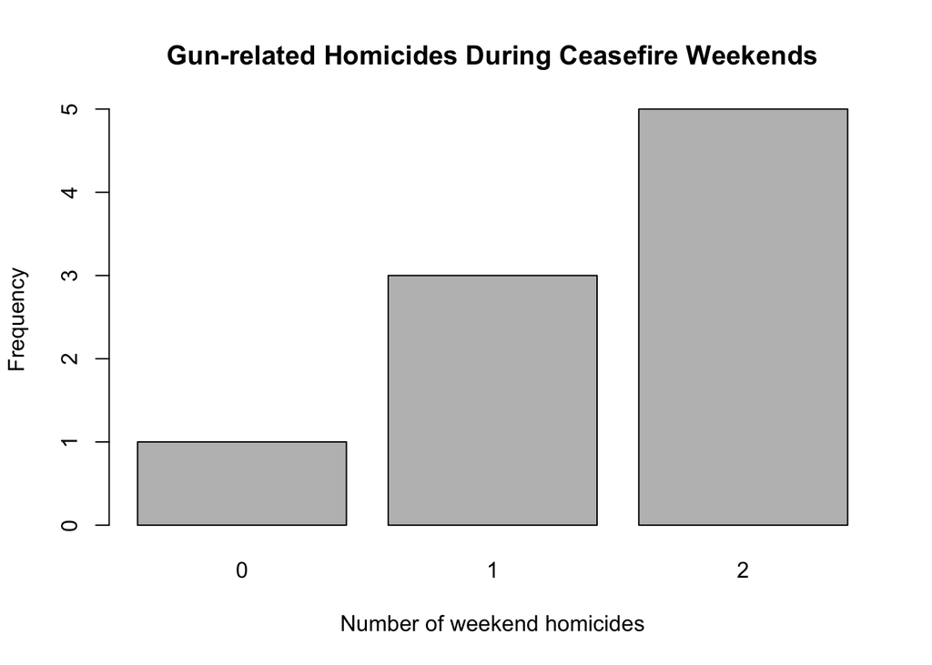

```r
# investigate only gun-related murders
df <- data %>% filter(Weapon=="FIREARM")
# change date format
df$CrimeDate <- as.Date(df$CrimeDate, format = "%m/%d/%Y")
# count homocides each day
crimesEachDay <- as.data.frame(table(df$CrimeDate))
colnames(crimesEachDay)[1] <- "Date"
crimesEachDay$Date <- as.Date(crimesEachDay$Date)
crimesEachDay <- crimesEachDay %>% complete(Date = seq(as.Date("2014-01-01"), as.Date("2019-10-24"), "day"), fill = list(Value = 0))
crimesEachDay[is.na(crimesEachDay$Freq),"Freq"] <- 0

########################################################################################
# Comparing number of homocides during Ceasefire weekends and non-Ceasefire weekends
########################################################################################
# list all Ceasefire weekend dates
event1 <- which(as.character(df$CrimeDate) %in% c("2017-08-04","2017-08-05","2017-08-06"))
event2 <- which(as.character(df$CrimeDate) %in% c("2017-11-03","2017-11-04","2017-11-05"))
event3 <- which(as.character(df$CrimeDate) %in% c("2018-02-02","2018-02-03","2018-02-04"))
event4 <- which(as.character(df$CrimeDate) %in% c("2018-05-11","2018-05-12","2018-05-13"))
event5 <- which(as.character(df$CrimeDate) %in% c("2018-08-03","2018-08-04","2018-08-05"))
event6 <- which(as.character(df$CrimeDate) %in% c("2018-11-02","2018-11-03","2018-11-04"))
event7 <- which(as.character(df$CrimeDate) %in% c("2019-02-01","2019-02-02","2019-02-03"))
event8 <- which(as.character(df$CrimeDate) %in% c("2019-05-10","2019-05-11","2019-05-12"))
event9 <- which(as.character(df$CrimeDate) %in% c("2019-08-02","2019-08-03","2019-08-04"))
df$isCeasefireWeekend <- 0
df$isCeasefireWeekend[c(event1,event2,event3,event4,event5,event6,event7,event8,event9)] <- 1
CeasefireCases <- c(length(event1),length(event2),length(event3),length(event4),length(event5),length(event6),length(event7),length(event8),length(event9))

df$isWeekend <- weekdays(df$CrimeDate) %in% c("Friday","Saturday","Sunday")
df$week <- paste0(year(df$CrimeDate),"-",week(df$CrimeDate))

# limit comparison to dates after first Ceasefire weekend
data2017 <-  df %>% filter(CrimeDate >= as.Date("2017-08-04"))
# non-Ceasefire weekends
temp <- subset(data2017, isCeasefireWeekend==0)
temp1 <- as.data.frame(unlist(table(temp$week,temp$isWeekend)))
temp1$Var1 <- as.character(temp1$Var1)
allWeeks <- c(paste0("2017-",32:52),paste0("2018-",1:53),paste0("2019-",1:43))
zeroCaseWeeks <- setdiff(allWeeks,unique(temp1$Var1))
nonCeasefireCases2017 <- c(table(temp$week,temp$isWeekend)[,2],rep(0,length(zeroCaseWeeks)))
# weekend homicide count distribution
barplot(table(CeasefireCases), main="Gun-related Homicides During Ceasefire Weekends",
        xlab="Number of weekend homicides", ylab="Frequency")
```

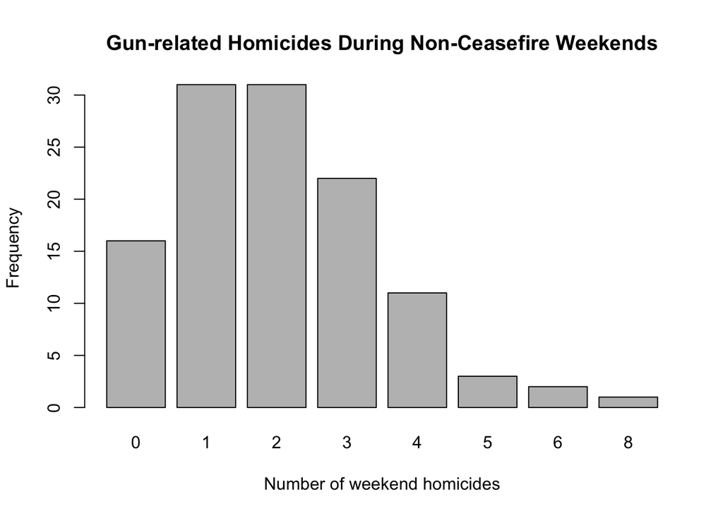

```r
barplot(table(nonCeasefireCases2017), main="Gun-related Homicides During Non-Ceasefire Weekends",
     xlab="Number of weekend homicides", ylab="Frequency")
```

```r
# rank sum test
wilcox.test(CeasefireCases, nonCeasefireCases2017, conf.int = TRUE, conf.level = 0.95)
```

```
##
##  Wilcoxon rank sum test with continuity correction
##
## data:  CeasefireCases and nonCeasefireCases2017
## W = 415, p-value = 0.2803
## alternative hypothesis: true location shift is not equal to 0
## 95 percent confidence interval:
##  -1.000035e+00  7.934993e-05
## sample estimates:
## difference in location
##          -2.747756e-05
```

Next, I wondered whether the Ceasefire events had a larger ripple effect. That is, do the reductions in gun-related deaths on Ceasefire weekends carry over to other days where no Ceasefire events are being held. To investigate this, I looked at the time period post the first-ever Ceasefire event (date indicated by orange line) and the same time frame (812 days) prior to the first-ever Ceasefire event (starting date indicated by blue line), and the time series plot suggests that overall counts of gun-related deaths did not change by much. An examination of the murder counts shows that there was an overall 4.2% reduction in murders, with the weekends experiencing a 7.7% reduction and the weekdays experiencing a 1.7% reduction. Again, we see that the distributions of daily murder counts both pre and post the first-ever Ceasefire event are not normal, but are similar in shape, so a Wilcoxon rank-sum test was used to compare the distributions, and test results indicated that the change in murder counts was not statistically significant.

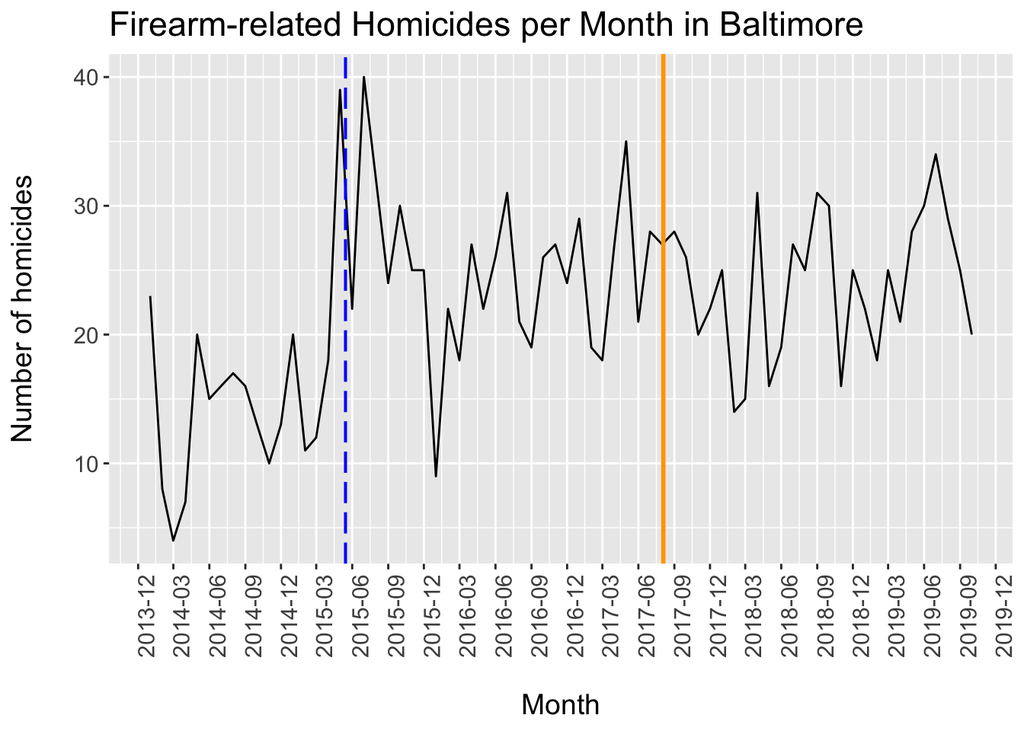

```r
########################################################################################
# Comparing number of homocides pre and post first Ceasefire event
########################################################################################
# time-lapse
tDiff <- (data2017$CrimeDate[1] - as.Date("2017-08-04"))
# it's been 812 days since the first Ceasefire event
startDate <- as.Date("2017-08-04") - tDiff - 1
preCeasefireCases <- pull(subset(crimesEachDay, Date >= startDate & Date < "2017-08-04")[,2])
postCeasefireCases <- pull(subset(crimesEachDay,  Date >= "2017-08-04")[,2])

# count homocides each month
crimesEachMonth <- crimesEachDay %>% group_by(month=floor_date(Date, "month")) %>% summarize(total=sum(Freq))
crimesEachMonth$month <- as.POSIXct(crimesEachMonth$month)
# plot homocides each month
ggplot(data=crimesEachMonth, aes(month, total)) + geom_line() + ggtitle("Firearm-related Homicides per Month in Baltimore") + ylab("Number of homicides\n") + scale_x_datetime(labels = date_format("%Y-%m"), breaks = date_breaks("3 months")) + theme(axis.text.x = element_text(angle = 90), text = element_text(size=14)) + xlab("\nMonth") + geom_vline(xintercept=as.POSIXct(as.Date("2017-08-04",format = "%Y-%m-%d")), color="orange", lwd=1) +
  geom_vline(xintercept=as.POSIXct(startDate), color="blue", lwd=0.7, linetype = "longdash")
```

```r
# weekday and weekend homocide counts
data2015 <-  df %>% filter(CrimeDate >= startDate & CrimeDate < "2017-08-04")
data2015$weekday <- weekdays(data2015$CrimeDate)
preCeasefireWeekOfDay <- as.data.frame(table(data2015$weekday))
colnames(preCeasefireWeekOfDay)[2] <- "Pre-Ceasefire"
data2017$weekday <- weekdays(data2017$CrimeDate)
postCeasefireWeekOfDay <- as.data.frame(table(data2017$weekday))
colnames(postCeasefireWeekOfDay)[2] <- "Post-Ceasefire"
preCeasefireWeekendCounts <- preCeasefireWeekOfDay[1,2]+preCeasefireWeekOfDay[3,2]+preCeasefireWeekOfDay[4,2]
preCeasefireCounts <- sum(preCeasefireWeekOfDay[,2])
preCeasefireWeekdayCounts <- preCeasefireCounts- preCeasefireWeekendCounts
postCeasefireWeekendCounts <- postCeasefireWeekOfDay[1,2]+postCeasefireWeekOfDay[3,2]+postCeasefireWeekOfDay[4,2]
postCeasefireCounts <- sum(postCeasefireWeekOfDay[,2])
postCeasefireWeekdayCounts <- postCeasefireCounts- postCeasefireWeekendCounts
dt <- rbind(cbind(preCeasefireCounts,preCeasefireWeekendCounts,preCeasefireWeekdayCounts),
            cbind(postCeasefireCounts,postCeasefireWeekendCounts,postCeasefireWeekdayCounts))
colnames(dt) <- c("Total number of homicides","Total number of homicides on weekends","Total number of homicides on weekdays")
rownames(dt) <- c("Baltimore \n (pre-Ceasefire)","Baltimore \n (post-Ceasefire)")
dt %>% kable(digits = 2) %>% kable_styling()
```

|  | Total number of homicides | Total number of homicides on weekends | Total number of homicides on weekdays |
| --- | --- | --- | --- |
| Baltimore (pre-Ceasefire) | 674 | 272 | 402 |
| Baltimore (post-Ceasefire) | 646 | 251 | 395 |

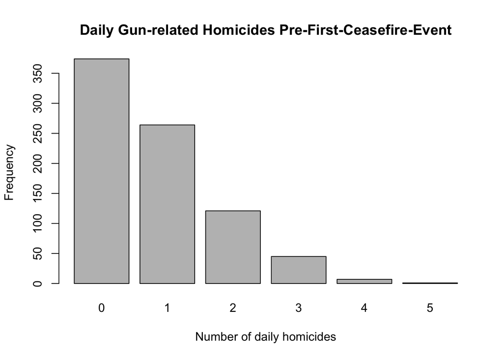

```r
# weekend homicide count distribution
barplot(table(preCeasefireCases), main="Daily Gun-related Homicides Pre-First-Ceasefire-Event",
        xlab="Number of daily homicides", ylab="Frequency")
```

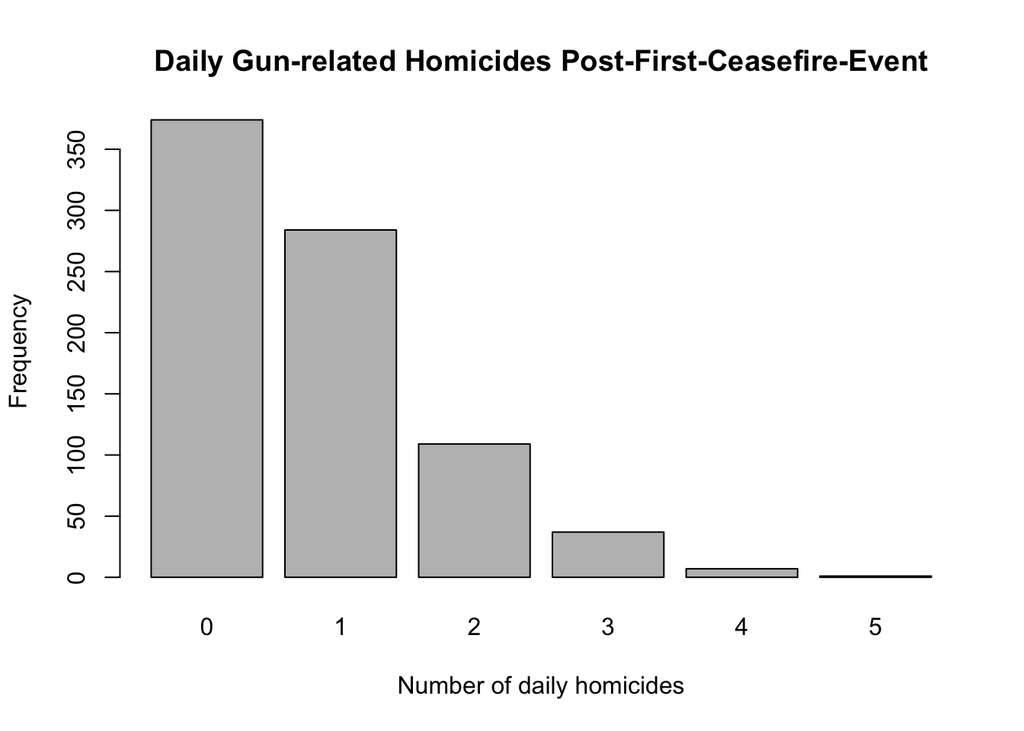

```r
barplot(table(postCeasefireCases), main="Daily Gun-related Homicides Post-First-Ceasefire-Event",
     xlab="Number of daily homicides", ylab="Frequency")
```

```r
# rank sum test to compare gun-related murders after first Ceasefire event and gun-related murders in the 812 days before the first Ceasefire event
wilcox.test(preCeasefireCases, postCeasefireCases, conf.int = TRUE, conf.level = 0.95)
```

```
##
##  Wilcoxon rank sum test with continuity correction
##
## data:  preCeasefireCases and postCeasefireCases
## W = 334186, p-value = 0.6067
## alternative hypothesis: true location shift is not equal to 0
## 95 percent confidence interval:
##  -5.608918e-05  2.339593e-05
## sample estimates:
## difference in location
##                      0
```

To judge how a similar Ceasefire policy would work in Boston, we need to investigate differences in the two cities. Boston crime incidents data was obtained from: https://data.boston.gov/dataset/crime-incident-reports-august-2015-to-date-source-new-system. The dataset contains records of crime incident reports in Boston from July of 2015 to date. However, according to the website, starting October 2019, this data set will not update until further notice due to system maintenance. Thus, the dataset used for this analysis contains data up to September of 2019. To compare the two cities, Baltimore homicide reports from the same time frame, July 2015 to September 2019, were used.

A time series plot of homicides in the two cities shows that neither city has experienced a drastic change in homicide counts since July of 2015, and Boston consistently has fewer homicide cases than Baltimore. Histograms of monthly homicide counts in both cities show that the counts are approximately normally distributed, so a t-test can be used to determine if the monthly means of gun-related murders in the two cities (24.6 in Baltimore and 4.4 in Boston) are significantly different from each other. Test results indicated that the difference was statistically significant, and a 95% confidence interval of the difference was given as (18.4, 22.0).

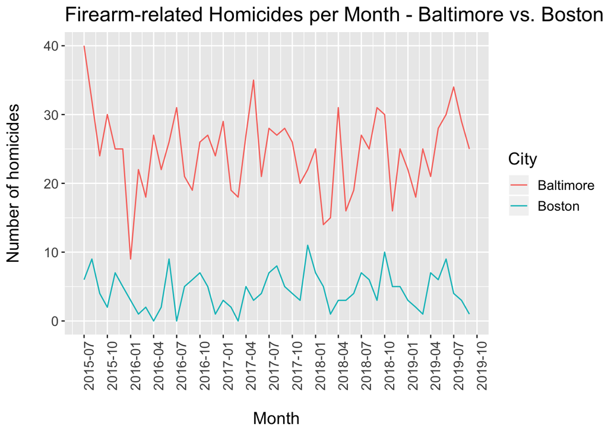

```r
########################################################################################
# Boston homicide analysis
########################################################################################
# tidy Boston crime data and obtain monthly shooting homicide counts
BostonData <- read_csv("tmp4n2nh8dd.csv")
BostonDF <- subset(BostonData, OFFENSE_CODE_GROUP=="Homicide")
BostonDF <- subset(BostonDF, SHOOTING == "Y")
BostonDF$YearMonth <- as.Date(paste0(BostonDF$YEAR,"-",BostonDF$MONTH,"-01"),format = "%Y-%m-%d")
monthly <- as.data.frame(table(BostonDF$YearMonth))
colnames(monthly)[1] <- "month"
monthly$month <- as.Date(monthly$month)
monthly <- monthly %>% complete(month = seq(as.Date("2015-07-01"), as.Date("2019-09-01"), "month"), fill = list(Value = 0))
monthly[is.na(monthly$Freq),"Freq"] <- 0
monthly$month <- as.POSIXct(monthly$month)
# compare Boston and Baltimore
compare <- merge(crimesEachMonth, monthly)
colnames(compare) <- c("Month","Baltimore","Boston")
compare <- melt(compare, id=c("Month"))
colnames(compare)[2] <- "City"
ggplot(data=compare, aes(Month, value)) + geom_line(aes(color=City)) + ggtitle("Firearm-related Homicides per Month - Baltimore vs. Boston") + ylab("Number of homicides\n") + scale_x_datetime(labels = date_format("%Y-%m"), breaks = date_breaks("3 months")) + theme(axis.text.x = element_text(angle = 90), text = element_text(size=14)) + xlab("\nMonth")
```

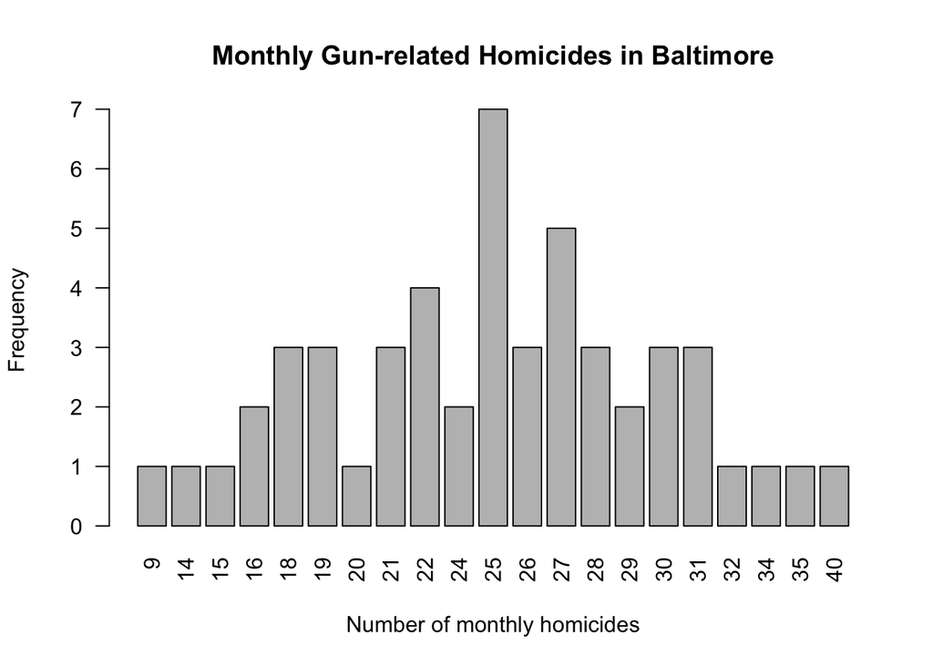

```r
BaltimoreCounts <- compare %>% filter(City=="Baltimore")
barplot(table(BaltimoreCounts$value), main="Monthly Gun-related Homicides in Baltimore",
        xlab="Number of monthly homicides", ylab="Frequency",las=2)
```

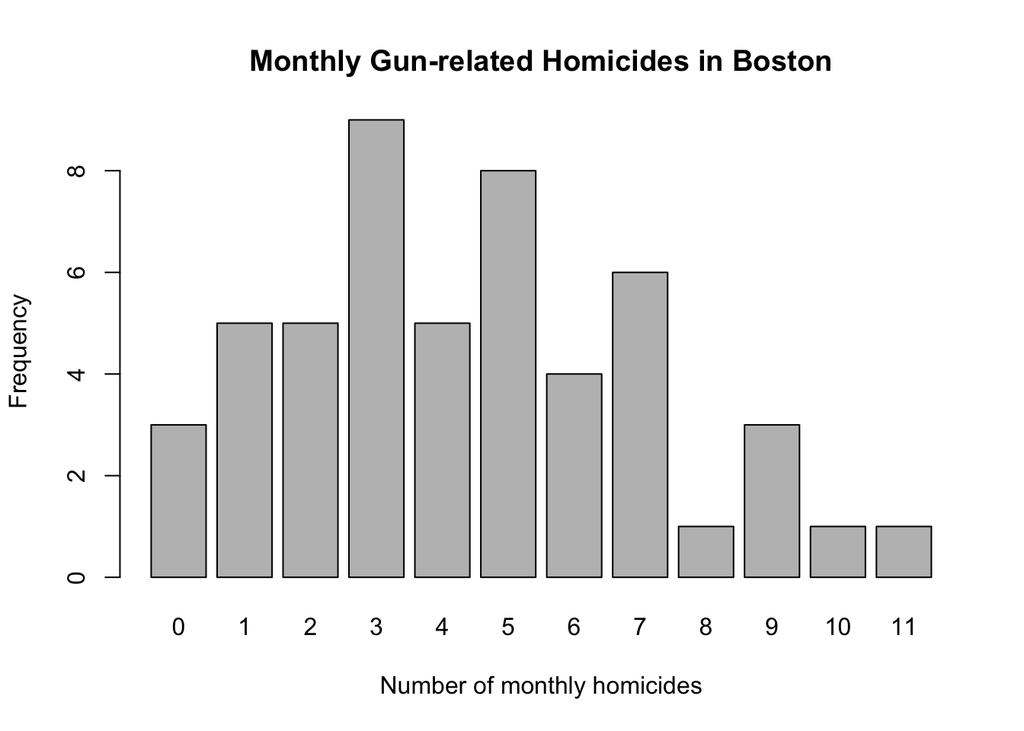

```r
BostonCounts <- compare %>% filter(City=="Boston")
barplot(table(BostonCounts$value), main="Monthly Gun-related Homicides in Boston",
        xlab="Number of monthly homicides", ylab="Frequency")
```

```r
t.test(BaltimoreCounts$value, BostonCounts$value)
```

```
##
##  Welch Two Sample t-test
##
## data:  BaltimoreCounts$value and BostonCounts$value
## t = 22.338, df = 70.506, p-value < 2.2e-16
## alternative hypothesis: true difference in means is not equal to 0
## 95 percent confidence interval:
##  18.39307 21.99909
## sample estimates:
## mean of x mean of y
## 24.588235  4.392157
```

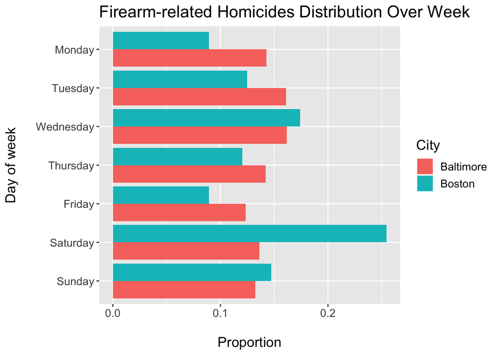

```r
########################################################################################
# Comparing homicide distribution over week in Baltimore and Boston
########################################################################################
# distribution in Baltimore
dataCompare <-  df %>% filter(CrimeDate >= "2015-07-01" & CrimeDate <= "2019-09-30")
dataCompare$weekday <- weekdays(dataCompare$CrimeDate)
BaltimoreWeekOfDay <- as.data.frame(table(dataCompare$weekday))
BaltimoreWeekOfDay$Freq <- BaltimoreWeekOfDay$Freq/sum(BaltimoreWeekOfDay$Freq)
colnames(BaltimoreWeekOfDay)[2] <- "Baltimore"
# distribution in Boston
BostonWeekOfDay <- as.data.frame(table(BostonDF$DAY_OF_WEEK))
BostonWeekOfDay$Freq <- BostonWeekOfDay$Freq/sum(BostonWeekOfDay$Freq)
colnames(BostonWeekOfDay)[2] <- "Boston"
# compare and plot
CompareWeekOfDay <- merge(BaltimoreWeekOfDay,BostonWeekOfDay)
CompareWeekOfDay <- melt(CompareWeekOfDay, id=c("Var1"))
CompareWeekOfDay$Var1 <- factor(CompareWeekOfDay$Var1,levels = c("Monday", "Tuesday", "Wednesday", "Thursday", "Friday", "Saturday", "Sunday"))
colnames(CompareWeekOfDay)[2] <- "City"
ggplot(data=CompareWeekOfDay, aes(x=Var1, y=value, fill=City)) + geom_bar(stat="identity",position=position_dodge()) + ggtitle("Firearm-related Homicides Distribution Over Week") + ylab("\nProportion") + xlab("Day of week\n") + theme(text = element_text(size=14)) + coord_flip() + scale_x_discrete(limits = rev(levels(CompareWeekOfDay$Var1)))
```

```r
# Baltimore model
BaltimoreDailyCounts <- as.data.frame(table(dataCompare$CrimeDate))
BaltimoreDailyCounts$Var1 <- as.Date(BaltimoreDailyCounts$Var1)
BaltimoreDailyCounts <- BaltimoreDailyCounts %>% complete(Var1 = seq(as.Date("2015-07-01"), as.Date("2019-09-30"), "day"), fill = list(Value = 0))
BaltimoreDailyCounts[is.na(BaltimoreDailyCounts$Freq),"Freq"] <- 0
BaltimoreDailyCounts$weekday <- weekdays(BaltimoreDailyCounts$Var1)
BaltimoreDailyCounts$weekday <- factor(BaltimoreDailyCounts$weekday,levels = c("Monday", "Tuesday", "Wednesday", "Thursday", "Friday", "Saturday", "Sunday"))
# testing model assumptions for Poisson
mean(BaltimoreDailyCounts$Freq)
```

```
## [1] 0.8074694
```

```r
var(BaltimoreDailyCounts$Freq)
```

```
## [1] 0.851439
```

```r
summary(glm(Freq ~ weekday, BaltimoreDailyCounts, family = quasipoisson()))
```

```
##
## Call:
## glm(formula = Freq ~ weekday, family = quasipoisson(), data = BaltimoreDailyCounts)
##
## Deviance Residuals:
##     Min       1Q   Median       3Q      Max
## -1.3523  -1.2412   0.0882   0.2773   3.2399
##
## Coefficients:
##                   Estimate Std. Error t value Pr(>|t|)
## (Intercept)      -0.215292   0.076624  -2.810  0.00502 **
## weekdayTuesday    0.125397   0.105233   1.192  0.23360
## weekdayWednesday  0.125820   0.105111   1.197  0.23148
## weekdayThursday  -0.005602   0.108514  -0.052  0.95883
## weekdayFriday    -0.143961   0.112478  -1.280  0.20077
## weekdaySaturday  -0.045722   0.109622  -0.417  0.67667
## weekdaySunday    -0.075398   0.110463  -0.683  0.49499
## ---
## Signif. codes:  0 '***' 0.001 '**' 0.01 '*' 0.05 '.' 0.1 ' ' 1
##
## (Dispersion parameter for quasipoisson family taken to be 1.050962)
##
##     Null deviance: 1812.5  on 1552  degrees of freedom
## Residual deviance: 1801.7  on 1546  degrees of freedom
## AIC: NA
##
## Number of Fisher Scoring iterations: 5
```

```r
# Boston model
BostonDailyCounts <- as.data.frame(table(BostonDF$OCCURRED_ON_DATE))
BostonDailyCounts$Var1 <- as.Date(BostonDailyCounts$Var1)
BostonDailyCounts <- BostonDailyCounts %>% complete(Var1 = seq(as.Date("2015-07-01"), as.Date("2019-09-30"), "day"), fill = list(Value = 0))
BostonDailyCounts[is.na(BostonDailyCounts$Freq),"Freq"] <- 0
BostonDailyCounts$weekday <- weekdays(BostonDailyCounts$Var1)
BostonDailyCounts$weekday <- factor(BostonDailyCounts$weekday,levels = c("Monday", "Tuesday", "Wednesday", "Thursday", "Friday", "Saturday", "Sunday"))
# testing model assumptions for Poisson
mean(BostonDailyCounts$Freq)
```

```
## [1] 0.1435897
```

```r
var(BostonDailyCounts$Freq)
```

```
## [1] 0.2372264
```

```r
summary(glm(Freq ~ weekday, BostonDailyCounts, family = quasipoisson()))
```

```
##
## Call:
## glm(formula = Freq ~ weekday, family = quasipoisson(), data = BostonDailyCounts)
##
## Deviance Residuals:
##     Min       1Q   Median       3Q      Max
## -0.7134  -0.5428  -0.4921  -0.4245   4.7462
##
## Coefficients:
##                   Estimate Std. Error t value Pr(>|t|)
## (Intercept)      -2.406945   0.283471  -8.491  < 2e-16 ***
## weekdayTuesday    0.340987   0.371151   0.919  0.35838
## weekdayWednesday  0.663335   0.348660   1.903  0.05729 .
## weekdayThursday   0.295610   0.374004   0.790  0.42942
## weekdayFriday    -0.004494   0.400889  -0.011  0.99106
## weekdaySaturday   1.038350   0.329471   3.152  0.00165 **
## weekdaySunday     0.491807   0.359244   1.369  0.17120
## ---
## Signif. codes:  0 '***' 0.001 '**' 0.01 '*' 0.05 '.' 0.1 ' ' 1
##
## (Dispersion parameter for quasipoisson family taken to be 1.607123)
##
##     Null deviance: 1067.1  on 1559  degrees of freedom
## Residual deviance: 1038.4  on 1553  degrees of freedom
## AIC: NA
##
## Number of Fisher Scoring iterations: 6
```

# Summarize

### Add your response here

# Recommendation

Give Monica your final recommenation. Be sure to point to key pieces of evidence (and any assumptions you made along the way) in your analysis when making your recommendation for or against.

### Add your response here

In addition, if we hope to implement such a policy, it is also important to consider the resources required to support and maintain the Ceasefire policy. Baltimore Ceasefire 365 was started by an organizing squad of six members who continue to serve at the core of the program. More people have joined in on the movement by applying to become ambassadors or being involved in volunteer work. Funding is provided by donations from the public, which totaled $29,906 this past year. Money raised from donations are used for producing outreach materials, and supporting families who lose loved ones to violence during ceasefire weekends. The labor and financial standards to implement a Ceasefire program do not seem to be high, so the question then lies in whether there is enough interest from Boston residents to run such a program. Perhaps a good solution would be to first spread the idea of Ceasefire Saturdays on social media to gauge how much interest there is from the public. If Boston residents are passionate about the subject, then I would suggest following through with the program, which may prove valuable in the years to come.

1. Gramlich, J. (2019, August 16). What the data says about gun deaths in the U.S. Retrieved November 8, 2019, from https://www.pewresearch.org/fact-tank/2019/08/16/what-the-data-says-about-gun-deaths-in-the-u-s/.